# RetailPulse: Demand Monitoring and Early Warning for Small Retailers

CSI3005 Advanced Data Visualization Techniques · Case Study-Based Lab Assessment

J Sai Vaishnavi (24MID0259)

25 October 2026

Store 235 · 162 products · 2024-03-28 to 2024-07-02 · real FreshRetailNet-50K data

**17.7%**of estimated demand went unmet because of stockouts

**19.2%**of trading hours (06:00–22:00) were out of stock

**31.1%**forecast error (WAPE, ETS) on the held-out week vs 39.6% for seasonal naive

**91**products have a High or Medium recommendation

# 1 Key business insights

- **Stockouts hide demand.** An estimated 17.7% of demand went unmet; 58 of 162 products lost more than 20% of their estimated demand (worst: P834 (44%), P249 (35%), P247 (35%)).
- **Timing matters.** Store sales peak around 09:00; products that sell out typically do so by 18:00, so restocking before the main peak matters most.
- **Forecasts are useful but imperfect.** ETS beats the seasonal-naive baseline on the held-out week (WAPE 31.1% vs 39.6%) but over-forecasts (bias 11.6%).
- **Risk scores rank, they do not predict exactly.** Next-day stockout risk reaches AUC 0.658 (baseline 0.549): useful for prioritising, not for certainty.
- **144 unusual product-days are unexplained** by a stockout, promotion, holiday or heavy rain, and are worth a manual check.

# 2 Problem and objective

Small retailers of perishable goods re-order daily, usually by judgement. Ordering too little empties shelves; ordering too much causes spoilage. A hidden complication is that **recorded sales are not demand**: when a product is out of stock, sales stop even though customers still want it, so low-sales days caused by stockouts can be mistaken for weak demand and lead to further under-ordering.

**Objective.** Using one store’s data, (1) prepare the data and quantify stockouts, (2) estimate demand that was lost to stockouts, (3) forecast short-term demand and evaluate the forecasts honestly, (4) flag unusual sales days, (5) estimate next-day stockout risk, and (6) turn these into explainable, prioritised recommendations for the store owner.

**Analytical questions.**

1. How has demand for each product changed over time, and which low-sales days reflect stockouts rather than weak demand?
2. Which product-days had sales unusually far from normal, and are those explained by stockouts, promotions or holidays?
3. How much demand is expected next week, and how reliable is that forecast compared with a simple baseline?
4. Which products are most likely to run out tomorrow, and which need attention first?

# 3 Dataset

**Source:** FreshRetailNet-50K, published by Dingdong-Inc on Hugging Face under CC BY 4.0 (Wang et al., 2025, arXiv:2505.16319). The dataset card describes 50,000 store–product series of 90 days with hourly sales and hourly stock status from 898 stores in 18 cities, plus a 7-day evaluation split.

**Data used in this report:** FreshRetailNet-50K (Dingdong-Inc, CC BY 4.0). Store 235, 162 products, 2024-03-28 to 2024-07-02 (training 2024-03-28–2024-06-25, evaluation 2024-06-26–2024-07-02).

```r
tibble::tribble(
  ~Attribute, ~Type, ~Use,
  "store_id, product_id, category ids", "Categorical (encoded)", "Select the store; group products",
  "dt", "Date", "Time axis; weekday features",
  "sale_amount", "Quantitative (globally normalised)", "Daily recorded sales",
  "hours_sale", "24 hourly values", "Hourly demand profiles; replay",
  "hours_stock_status", "24 binary flags (1 = out of stock)", "Stockout hours; demand recovery",
  "stock_hour6_22_cnt", "Integer 0–16", "Cross-checked against hourly flags",
  "discount, activity_flag, holiday_flag", "Ratio; binary", "Promotion and holiday explanations",
  "precpt, avg_temperature", "Quantitative", "Weather context")
```

| Attribute | Type | Use |
| --- | --- | --- |
| store_id, product_id, category ids | Categorical (encoded) | Select the store; group products |
| dt | Date | Time axis; weekday features |
| sale_amount | Quantitative (globally normalised) | Daily recorded sales |
| hours_sale | 24 hourly values | Hourly demand profiles; replay |
| hours_stock_status | 24 binary flags (1 = out of stock) | Stockout hours; demand recovery |
| stock_hour6_22_cnt | Integer 0–16 | Cross-checked against hourly flags |
| discount, activity_flag, holiday_flag | Ratio; binary | Promotion and holiday explanations |
| precpt, avg_temperature | Quantitative | Weather context |

**Not available in the data:** inventory on hand, prices, costs, supplier lead times and shelf life. Sales are normalised by an undisclosed factor, so all values are in *normalised units*. No order quantities or money values are produced anywhere in this project.

# 4 Data preparation

```r
tibble::tibble(
  Check = c("Raw rows (product-days)", "Duplicate product-days removed", "Hourly lists not of length 24", "Hourly sum ≠ daily total (>0.05)",
            "Negative sales", "Discount outside (0, 1]", "stock_hour6_22_cnt ≠ recount", "Missing product-days", "Clean rows"),
  Count = c(q$rows_raw, q$duplicates_removed, q$hourly_wrong_length, q$hourly_daily_mismatch, q$negative_sales_rows,
            q$discount_out_of_range, q$stock_count_mismatch, q$missing_product_days, q$rows_clean),
  Treatment = c("–", "Kept first occurrence", "Row removed", "Daily total replaced by hourly sum", "Set to 0", "Set to 1.0",
                "Recomputed from hourly flags (06:00–21:59)", "Reported", "–"))
```

| Check | Count | Treatment |
| --- | --- | --- |
| Raw rows (product-days) | 15714 | – |
| Duplicate product-days removed | 0 | Kept first occurrence |
| Hourly lists not of length 24 | 0 | Row removed |
| Hourly sum ≠ daily total (>0.05) | 0 | Daily total replaced by hourly sum |
| Negative sales | 0 | Set to 0 |
| Discount outside (0, 1] | 0 | Set to 1.0 |
| stock_hour6_22_cnt ≠ recount | 0 | Recomputed from hourly flags (06:00–21:59) |
| Missing product-days | 0 | Reported |
| Clean rows | 15714 | – |

The hourly lists were expanded into a 24-column sales matrix and a 24-column stock-status matrix. Stockout hours were counted only within trading hours (06:00–21:59), because overnight flags may mean “closed” rather than “sold out”. Calendar features (weekday, weekend), promotion depth (1 − discount), and leakage-safe lags and rolling means (each using only days *before* the day described) were added. Overall, **19.2% of trading hours were out of stock**, and 44% of product-days had at least one out-of-stock trading hour.

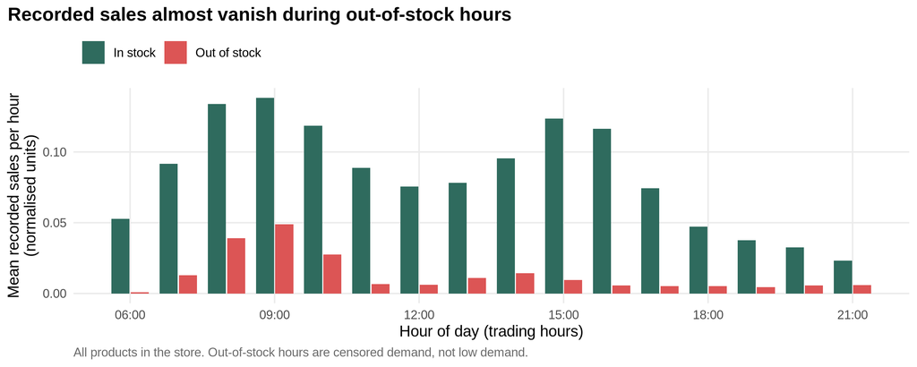

```r
iv <- pq("instock_vs_out")
ggplot(iv, aes(hour, mean_sales, fill = status)) + geom_col(position = position_dodge(0.8), width = 0.75) +
  scale_fill_manual(values = c("In stock" = COL$dem, "Out of stock" = COL$so), name = NULL) +
  scale_x_continuous(breaks = seq(6, 21, 3), labels = function(x) sprintf("%02d:00", x)) +
  labs(title = "Recorded sales almost vanish during out-of-stock hours",
       x = "Hour of day (trading hours)", y = "Mean recorded sales per hour\n(normalised units)",
       caption = "All products in the store. Out-of-stock hours are censored demand, not low demand.")
```

**Interpretation.** Recorded sales per out-of-stock hour average 0.008 against 0.087 per in-stock hour. Any analysis that treats recorded sales as demand would therefore under-estimate demand on stockout days.

# 5 Exploratory analysis

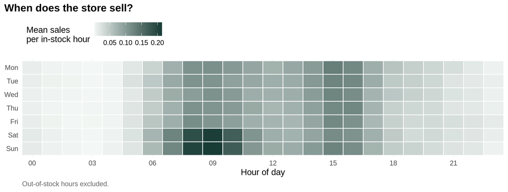

```r
w <- pq("store_weekday_hour") |> mutate(day = factor(c("Mon","Tue","Wed","Thu","Fri","Sat","Sun")[weekday], levels = rev(c("Mon","Tue","Wed","Thu","Fri","Sat","Sun"))))
ggplot(w, aes(hour, day, fill = mean_sales)) + geom_tile(colour = "white", linewidth = 0.4) +
  scale_fill_gradient(low = "#F3F7F5", high = COL$forest, name = "Mean sales\nper in-stock hour") +
  scale_x_continuous(breaks = seq(0, 21, 3), labels = function(x) sprintf("%02d", x), expand = c(0, 0)) +
  labs(title = "When does the store sell?", x = "Hour of day", y = NULL, caption = "Out-of-stock hours excluded.")
```

**Interpretation.** Demand concentrates around 09:00 and 08:00; the busiest weekday on average is Sunday. Restocking before the main peak matters most.

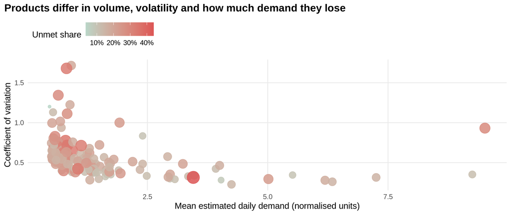

```r
v <- pq("variability")
ggplot(v, aes(mean_latent, cv, size = unmet_share, colour = unmet_share)) + geom_point(alpha = 0.85) +
  scale_colour_gradient(low = "#B9D6C8", high = COL$so, labels = percent, name = "Unmet share") +
  scale_size(range = c(1.5, 7), guide = "none") +
  labs(title = "Products differ in volume, volatility and how much demand they lose",
       x = "Mean estimated daily demand (normalised units)", y = "Coefficient of variation")
```

# 6 Stockout-aware demand estimation

**Method.** For each product, an hourly demand profile (each hour’s share of daily sales) is estimated from fully in-stock *training* days, separately for weekdays and weekends, and shrunk towards the product’s overall profile. On a day with out-of-stock trading hours, the day’s demand level is inferred from the in-stock hours (level = in-stock sales ÷ in-stock profile share), and the missing hours are filled with level × profile share. If under 25% of the profile was in stock, a trailing 28-day median of in-stock days is used instead. *Assumption:* the hourly shape of demand is stable.

**Validation.** On 5860 fully in-stock training days, trading hours from a random cut-off (12:00–20:00) were hidden as if out of stock. The day total was then re-estimated using a profile that excludes that day.

```r
lm <- as.data.frame(lv$metrics)
tibble::tibble(Method = c("Hourly-profile estimate", "Observed sales only (no adjustment)"),
               MAE = num(lm$MAE, 3), WAPE = pct(lm$WAPE), Bias = pct(lm$bias))
```

| Method | MAE | WAPE | Bias |
| --- | --- | --- | --- |
| Hourly-profile estimate | 0.217 | 14.6% | 0.7% |
| Observed sales only (no adjustment) | 0.392 | 26.3% | -26.3% |

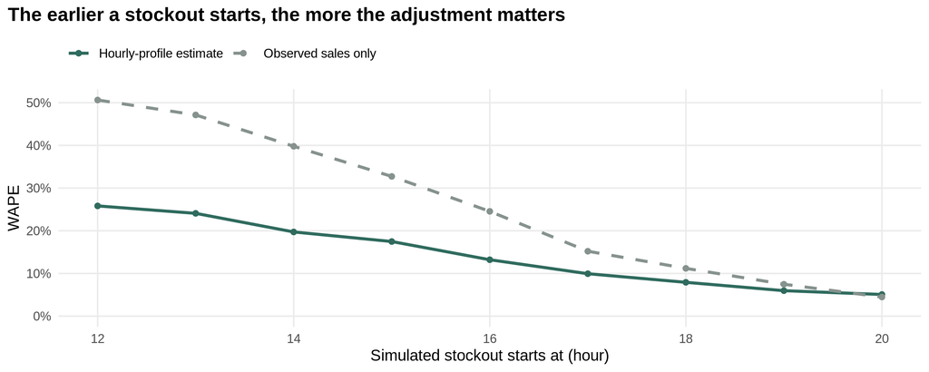

```r
bc <- pq("latent_validation_by_cutoff") |> pivot_longer(c(wape_profile, wape_observed), names_to = "method", values_to = "wape") |>
  mutate(method = recode(method, wape_profile = "Hourly-profile estimate", wape_observed = "Observed sales only"))
ggplot(bc, aes(cutoff_hour, wape, colour = method, linetype = method)) + geom_line(linewidth = 1) + geom_point() +
  scale_colour_manual(values = c(COL$dem, COL$muted), name = NULL) + scale_linetype_manual(values = c("solid", "dashed"), name = NULL) +
  scale_y_continuous(labels = percent, limits = c(0, NA)) +
  labs(title = "The earlier a stockout starts, the more the adjustment matters", x = "Simulated stockout starts at (hour)", y = "WAPE")
```

**Interpretation.** Estimating the hidden hours reduces the day-total error from 26.3% (ignoring the stockout) to 14.6%, with bias 0.7% versus -26.3%. The gain is largest for early-afternoon stockouts. Across the whole period, estimated demand exceeds recorded sales by 17.7% of estimated demand. These are estimates and are always labelled as such.

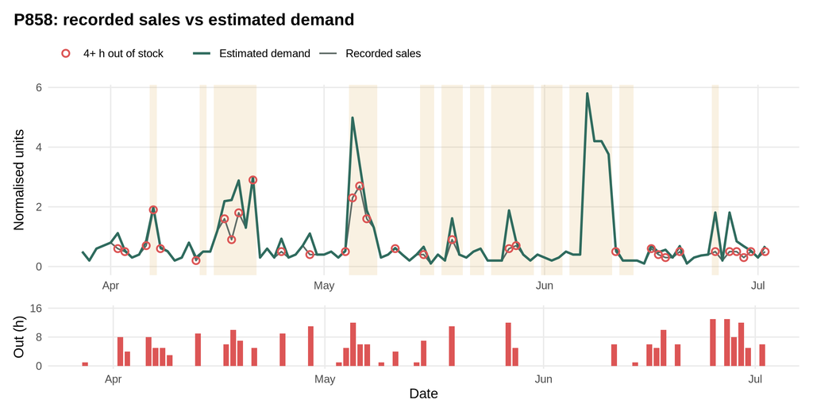

```r
pid <- recs$product_id[1]
dp <- daily |> filter(product_id == pid)
p1 <- ggplot(dp, aes(dt)) +
  geom_rect(data = dp |> filter(promo == 1), aes(xmin = dt - 0.5, xmax = dt + 0.5, ymin = -Inf, ymax = Inf), fill = COL$promo, alpha = 0.15, inherit.aes = FALSE) +
  geom_line(aes(y = sale_amount, colour = "Recorded sales"), linewidth = 0.6) +
  geom_line(aes(y = latent, colour = "Estimated demand"), linewidth = 0.9) +
  geom_point(data = dp |> filter(stock_h >= 4), aes(y = sale_amount, shape = "4+ h out of stock"), colour = COL$so, size = 2, stroke = 1) +
  scale_colour_manual(values = c("Recorded sales" = COL$rec, "Estimated demand" = COL$dem), name = NULL) +
  scale_shape_manual(values = c("4+ h out of stock" = 1), name = NULL) + expand_limits(y = 0) +
  labs(title = sprintf("P%s: recorded sales vs estimated demand", pid), x = NULL, y = "Normalised units")
p2 <- ggplot(dp, aes(dt, stock_h)) + geom_col(fill = COL$so, width = 0.8) + scale_y_continuous(limits = c(0, 16), breaks = c(0, 8, 16)) +
  labs(x = "Date", y = "Out (h)")
p1 / p2 + plot_layout(heights = c(3, 1))
```

**Interpretation.** For the highest-priority product (P858), stockouts occurred on 32 of 97 days with 4+ out-of-stock hours. On those days recorded sales (grey) drop while estimated demand (green) stays near its usual level: the drops are supply-side, not weaker demand. Gold bands mark promotions.

# 7 Demand forecasting

**Method.** For each product, the series of estimated daily demand was forecast with a **seasonal-naive** baseline (same weekday last week) and with **ETS** (automatic exponential smoothing via `fable`). Evaluation: rolling-origin cross-validation inside the training period (origins 2024-05-28, 2024-06-04, 2024-06-11, 2024-06-18, 7-day horizon), then a final hold-out test on the untouched evaluation week. The model was chosen on cross-validation only (**ETS**). Scores use **in-stock days only**, where recorded sales equal demand.

```r
cv <- pq("forecast_cv_overall") |> mutate(Window = "Rolling-origin CV (training)")
ev <- pq("forecast_eval_overall") |> mutate(Window = "Hold-out (evaluation week)")
bind_rows(cv, ev) |> transmute(Window, Model = ifelse(.model == "ets", "ETS", "Seasonal naive"), `In-stock days` = n_instock,
  MAE = num(MAE, 3), RMSE = num(RMSE, 3), WAPE = pct(WAPE), Bias = pct(bias), `80% PI coverage` = pct(coverage80, 0))
```

| Window | Model | In-stock days | MAE | RMSE | WAPE | Bias | 80% PI coverage |
| --- | --- | --- | --- | --- | --- | --- | --- |
| Rolling-origin CV (training) | ETS | 2668 | 0.482 | 0.796 | 38.8% | 19.6% | 85% |
| Rolling-origin CV (training) | Seasonal naive | 2668 | 0.565 | 0.958 | 45.5% | 17.6% | 86% |
| Hold-out (evaluation week) | ETS | 656 | 0.421 | 0.617 | 31.1% | 11.6% | 89% |
| Hold-out (evaluation week) | Seasonal naive | 656 | 0.537 | 0.803 | 39.6% | 15.0% | 87% |

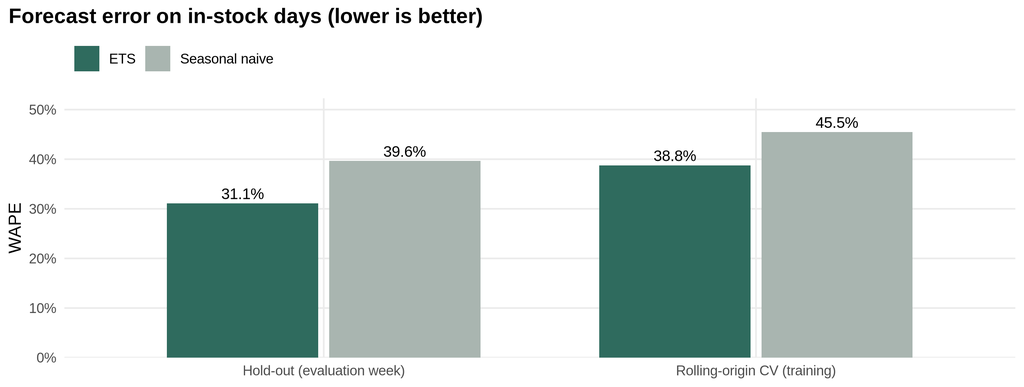

```r
bind_rows(cv, ev) |> mutate(Model = ifelse(.model == "ets", "ETS", "Seasonal naive")) |>
  ggplot(aes(Window, WAPE, fill = Model)) + geom_col(position = position_dodge(0.75), width = 0.7) +
  geom_text(aes(label = pct(WAPE)), position = position_dodge(0.75), vjust = -0.4, size = 3.4) +
  scale_fill_manual(values = c(ETS = COL$dem, "Seasonal naive" = COL$base), name = NULL) +
  scale_y_continuous(labels = percent, expand = expansion(mult = c(0, 0.15))) +
  labs(title = "Forecast error on in-stock days (lower is better)", x = NULL, y = "WAPE")
```

**Interpretation.** On the evaluation week, ETS has WAPE 31.1% against 39.6% for the seasonal-naive baseline, so ETS improves on the baseline. The 80% prediction intervals covered 89% of in-stock days. Both models show positive bias on in-stock days. This is expected: the busiest days are the ones that sell out and are excluded, so the scored days are quieter than average. WAPE is unstable for products with many zero-sale days, so reliability is reported per product in the app.

# 8 Anomaly detection

**Method.** Recorded sales are divided by a weekday factor estimated from the previous 56 days, then compared with the median of the previous 28 in-stock days (robust z = (value − median) ÷ (1.4826 × MAD), floored). Days with |z| ≥ 3 are flagged and labelled with the strongest recorded explanation.

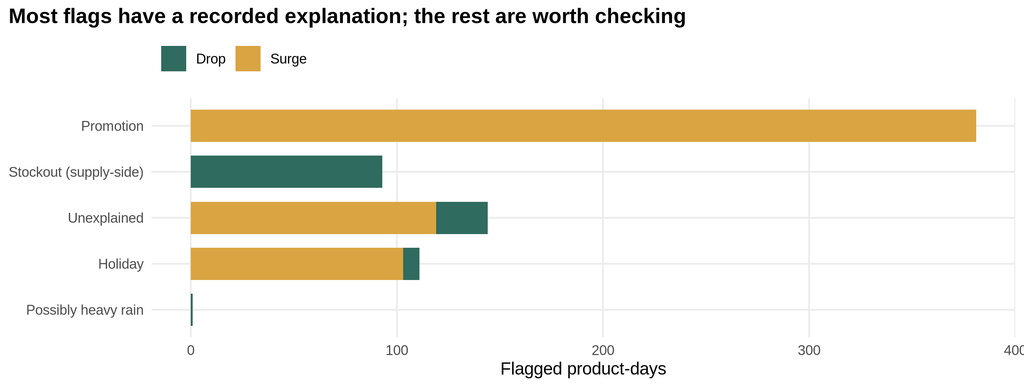

```r
an |> count(cause, direction) |> mutate(direction = ifelse(direction == "surge", "Surge", "Drop")) |>
  ggplot(aes(reorder(cause, n), n, fill = direction)) + geom_col(width = 0.7) + coord_flip() +
  scale_fill_manual(values = c(Surge = COL$promo, Drop = COL$dem), name = NULL) +
  labs(title = "Most flags have a recorded explanation; the rest are worth checking", x = NULL, y = "Flagged product-days")
```

**Interpretation.** 730 product-days were flagged; 586 coincide with a stockout, promotion, holiday or heavy rain, and 144 are unexplained. There is no ground truth for anomalies, so no detection accuracy is claimed. These are statistical signals for the owner to check, not confirmed problems.

# 9 Next-day stockout risk

```r
rm_ <- pq("risk_metrics")
rm_ |> transmute(Set = recode(set, logistic_validation = "Logistic · validation", logistic_test = "Logistic · evaluation week", frequency_baseline_test = "Frequency baseline · evaluation week"),
                 n, `Event rate` = pct(base_rate), AUC = num(AUC, 3), Brier = num(brier, 3), Precision = pct(precision, 0), Recall = pct(recall, 0), F1 = num(F1, 3),
                 TP, FP, FN, TN)
```

| Set | n | Event rate | AUC | Brier | Precision | Recall | F1 | TP | FP | FN | TN |
| --- | --- | --- | --- | --- | --- | --- | --- | --- | --- | --- | --- |
| Logistic · validation | 2268 | 34.9% | 0.652 | 0.212 | 46% | 66% | 0.538 | 519 | 618 | 273 | 858 |
| Logistic · evaluation week | 1134 | 35.0% | 0.658 | 0.212 | 48% | 63% | 0.544 | 251 | 274 | 146 | 463 |
| Frequency baseline · evaluation week | 1134 | 35.0% | 0.549 | 0.231 | 35% | 100% | 0.519 | 397 | 737 | 0 | 0 |

**Method.** The target is whether a product is out of stock for 4+ of 16 trading hours *tomorrow*. A logistic regression uses only information up to yesterday (recent stockout frequency and hours, yesterday’s stockout, recent demand change), plus tomorrow’s planned promotion, holiday and weekend flags. The split is chronological: fit 2024-04-25–2024-06-11, choose the threshold (0.3) on validation 2024-06-12–2024-06-25, and test on the evaluation week. Class balance is 34.2% events in the fit window, so precision, recall and F1 are reported rather than accuracy.

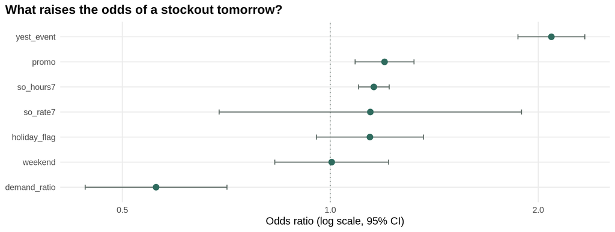

```r
co <- pq("risk_coefficients") |> filter(term != "(Intercept)")
ggplot(co, aes(odds_ratio, reorder(term, odds_ratio))) + geom_vline(xintercept = 1, linetype = "dotted", colour = COL$muted) +
  geom_errorbarh(aes(xmin = or_lo95, xmax = or_hi95), height = 0.2, colour = COL$rec) + geom_point(colour = COL$dem, size = 2.6) +
  scale_x_log10() + labs(title = "What raises the odds of a stockout tomorrow?", x = "Odds ratio (log scale, 95% CI)", y = NULL)
```

**Interpretation.** On the evaluation week, the logistic model reaches F1 0.544 and AUC 0.658, against F1 0.519 and AUC 0.549 for the historical-frequency baseline. The score describes historical sell-out patterns; it does not know current stock on hand, which the dataset does not record.

# 10 Product-level risk findings

```r
rn <- pq("risk_next")
prods |> left_join(rn |> select(product_id, so_rate7), by = "product_id") |> arrange(desc(risk)) |> head(12) |>
  transmute(Product = label, Category = category, `Next-day stockout risk` = pct(risk, 0), `Stockout days, last 7` = round(so_rate7 * 7),
            `Unmet share (whole period)` = pct(unmet_share), `Days with a sell-out` = pct(sellout_share, 0),
            `Median sell-out hour` = ifelse(is.na(median_sellout_hour), "rarely sells out", sprintf("%02.0f:00", median_sellout_hour)))
```

| Product | Category | Next-day stockout risk | Stockout days, last 7 | Unmet share (whole period) | Days with a sell-out | Median sell-out hour |
| --- | --- | --- | --- | --- | --- | --- |
| P19 | Category 4 | 71% | 5 | 19.7% | 57% | 18:00 |
| P77 | Category 8 | 61% | 5 | 20.8% | 45% | rarely sells out |
| P135 | Category 4 | 60% | 6 | 12.9% | 30% | rarely sells out |
| P858 | Category 15 | 60% | 5 | 18.0% | 39% | rarely sells out |
| P775 | Category 4 | 59% | 5 | 18.6% | 55% | 18:00 |
| P41 | Category 4 | 58% | 6 | 19.6% | 38% | rarely sells out |
| P249 | Category 16 | 55% | 6 | 34.8% | 65% | 17:00 |
| P422 | Category 16 | 55% | 6 | 23.4% | 49% | rarely sells out |
| P500 | Category 4 | 54% | 4 | 20.4% | 35% | rarely sells out |
| P215 | Category 4 | 52% | 4 | 23.1% | 73% | 13:00 |
| P425 | Category 16 | 51% | 3 | 33.6% | 61% | 17:00 |
| P285 | Category 24 | 51% | 6 | 26.8% | 45% | rarely sells out |

**Interpretation.** These products have the highest estimated probability of being out of stock for 4+ trading hours tomorrow (2024-07-03), assuming no promotion or holiday. The model threshold is 30%; 72 of 162 products are above it. The score reflects historical sell-out patterns, not stock on hand.

# 11 Decision support

Transparent rules (documented in the app and README) convert the results into actions: *consider replenishing earlier* (frequent recent stockouts with unmet demand), *investigate an unexplained drop*, *review a possible surge*, *plan for lower demand*, *use caution* (unreliable forecast), or *maintain the current approach*. Each recommendation shows its reason, evidence, urgency, reliability and the rule that produced it. The thresholds are design choices, not proven boundaries.

```r
recs |> distinct(product_id, .keep_all = TRUE) |> filter(action != "Maintain current approach") |> head(10) |>
  transmute(Product = paste0("P", product_id), Action = action, Urgency = urgency, Reason = reason, Reliability = reliability)
```

| Product | Action | Urgency | Reason | Reliability |
| --- | --- | --- | --- | --- |
| P858 | Consider replenishing earlier | High | Out of stock for 4+ trading hours on 5 of the last 7 days; about 45% of estimated demand went unmet. | Low |
| P285 | Consider replenishing earlier | High | Out of stock for 4+ trading hours on 6 of the last 7 days; about 44% of estimated demand went unmet. | Low |
| P21 | Consider replenishing earlier | High | Out of stock for 4+ trading hours on 5 of the last 7 days; about 34% of estimated demand went unmet. | Medium |
| P105 | Consider replenishing earlier | High | Out of stock for 4+ trading hours on 5 of the last 7 days; about 30% of estimated demand went unmet. | Medium |
| P508 | Consider replenishing earlier | High | Out of stock for 4+ trading hours on 4 of the last 7 days; about 22% of estimated demand went unmet. | Low |
| P373 | Consider replenishing earlier | High | Out of stock for 4+ trading hours on 5 of the last 7 days; about 29% of estimated demand went unmet. | Low |
| P697 | Consider replenishing earlier | High | Out of stock for 4+ trading hours on 3 of the last 7 days; about 40% of estimated demand went unmet. | Low |
| P612 | Consider replenishing earlier | High | Out of stock for 4+ trading hours on 3 of the last 7 days; about 39% of estimated demand went unmet. | Low |
| P345 | Consider replenishing earlier | High | Out of stock for 4+ trading hours on 3 of the last 7 days; about 21% of estimated demand went unmet. | Low |
| P19 | Consider replenishing earlier | High | Out of stock for 4+ trading hours on 5 of the last 7 days; about 52% of estimated demand went unmet. | High |

# 12 Findings and conclusion

- Stockouts affect 19.2% of trading hours, and recorded sales almost stop during them. Estimated unmet demand is 17.7% of estimated demand.
- The hourly-profile method recovers hidden demand with 14.6% WAPE, against 26.3% when stockouts are ignored.
- ETS outperforms the seasonal-naive baseline on the evaluation week (WAPE 31.1% vs 39.6%).
- 86 products are flagged to *consider replenishing earlier*; 25 unexplained sales drops deserve a check.

**Conclusion.** Treating stockout-censored sales as demand understates demand and invites further stockouts. Combining hourly stock flags with an hourly demand profile gives a validated estimate of what was lost, a better basis for forecasting, and explainable early-warning actions. The main limitations are normalised units, no inventory or cost data, 90 days of history, and chain-store origin, so the outputs are directional decision support, not order quantities.

# 13 Limitations

- Sales are globally normalised by an undisclosed factor: all values are normalised units, not money, kilograms or item counts.
- There is no inventory, price, cost, lead-time or shelf-life field, so no order quantities, dates or financial losses are produced.
- Overnight stock-status flags may mean “closed”; only 06:00–21:59 is used for stockout analysis.
- Estimated demand assumes a stable hourly profile; its error is measured above and it is always labelled as an estimate.
- 90 training days allow weekly patterns only. Forecasts beyond 7 days were not evaluated.
- Promotion effects are observational associations, not causal effects. The monitoring page replays historical data and is not a live feed.
- The stores belong to one large operator, so results are a proxy for a small independent shop.

# 14 References

1. Wang, Y. et al. (2025). *FreshRetailNet-50K: A Stockout-Annotated Censored Demand Dataset for Latent Demand Recovery and Forecasting in Fresh Retail.* arXiv:2505.16319.
2. Dingdong-Inc (2025). *FreshRetailNet-50K* (v1.0, CC BY 4.0). https://huggingface.co/datasets/Dingdong-Inc/FreshRetailNet-50K
3. Hyndman, R. J. and Athanasopoulos, G. (2021). *Forecasting: Principles and Practice*, 3rd ed. OTexts.
4. Cleveland, W. S. and McGill, R. (1984). Graphical perception. *Journal of the American Statistical Association*, 79(387), 531–554.

*Generated 2026-10-25 16:32:36 Asia with R version 4.4.3 (2025-02-28). The R code for the analysis is in `R/` and `pipeline/`; the code for each figure is shown with “Code” buttons above.*